# Learning to Perfect Manipulation: Implications for Fertility, Savings, and Old-Age Social Security

Lakshmi K. Raut[^1]

2021-08-11

#### Abstract

In this paper we consider an overlapping generations model with endogenous fertility and two-sided altruism and show the limitations of applying commonly used open loop Nash equilibrium in characterizing equilibrium transfers from parents to children in the form of bequest, and transfers from children to parents as voluntary old-age support. Since in our model children are concerned with parents’ old-age consumption, agents have incentives to save less for old age and to have more children so as to strategically induce their children to transfer more old-age support. We formulate such strategic behavior within a sequential multi-stage game and introduce a notion of learning equilibrium to characterize equilibrium manipulative behavior and then study the consequences of such strategic manipulations on private intergenerational transfers, fertility and savings decisions, and on Pareto optimality of equilibrium allocation. We show that the learning equilibrium notion of the paper simplifies computation of subgame perfect equilibrium, subgame perfect equilibrium is the long-run outcome of dynamic learning equilibrium paths (this aids in selecting, sometimes, a unique equilibrium among multiple subgame perfect equilibria), and an open-loop Nash equilibrium involves “incredible” threats from children. We provide an alternative explanation for the existence of publicly provided social security program and examine its role to correct distortions created by strategic manipulation.

**Acknowledgement and disclaimer**[^2]

# 1 Introduction

In standard pure exchange overlapping generations (OLG) economies agents are assumed to have life-cycle utility functions. These models do not explain private intergenerational transfers within family and have no bearings on the effects of public transfers policies such as social security on private intergenerational transfers, savings and fertility. Moreover, competitive equilibrium fails to be Pareto optimal; however, a suitably designed pay-as-you-go (PAYG) social security program can remove inefficiencies by allowing transfers from children to parents that are necessary for Pareto optimality but would not be possible in a decentralized competitive equilibrium due to lack of individual incentives for such transfers (see for instance, Samuelson (1958)). %Samuelson [1958]).

In another framework Becker (1974) %Becker [1974] establishes his ‘’Rotten Kid Theorem’’ that under certain circumstances when parents care about their children’s welfare, children take actions that maximize the joint family income even though children do not care about their parents, provided parents leave positive bequest to their children. One implication of his Rotten Kid Theorem is that a forced transfer between children and parents have no ultimate effect on equilibrium outcome, since parents can off-set this forced intergenerational transfer by suitably adjusting their bequest level.[^3] Barro (1974) %Barro [1974] uses the above kind of intergenerational altruism in an OLG framework and shows that social security has no effect on savings so long as in equilibrium agents leave positive bequest in all periods. Furthermore, since Barro model is equivalent to one with finite number of infinitely lived agents, a competitive equilibrium is Pareto optimal; hence social security is not required for the purpose of attaining Pareto optimality of equilibrium allocation.

Neither strand of above literature explain why transfers from children to parents are observed in many economies, and why the amount of transfers declines with the introduction of public transfer policies; why a PAYG social security program exists, and whether it is possible for the current living generations to legislate a PAYG social security benefits scheme for the current and all future generations such that the future generations will have no incentives to amend it; and if one such program exists, does it lead to optimal allocation?

A few attempts have been made, however, to explain the existence of PAYG social security programs in frameworks that treat fertility exogenously. One type of explanations postulate that there could be economy of scale and other sources of market failures in pension provision (see, Diamond (1977)) %Diamond [1977] or there might be adverse selection/moral hazard problems in private provision of retirement income insurance and these could be mitigated by compulsory participation (see Diamond and Mirrlees (1978)). %Diamond and Mirrlees [1978]). These can explain introduction of fully funded system but cannot explain the existence of PAYG system.

Among the other type of explanations, Browning (1975) %Browning [1975] considers a voting model of social security in an OLG framework in which the old outvote the young to enact a PAYG social security system. It is not, however, clear in Browning’s framework why then the old do not use their power to enact a legislation to extract all income from the young. Hansson and Stuart (1989) %Hansson and Stuart [1989] provide an alternative explanation by modeling PAYG social security legislation as a trade among living generations. They consider an OLG model in which agents are assumed to derive utility not only from their own young age and old-age consumption but also from properly discounted young age and old-age consumption of their parents and of all future generations. They find conditions under which the young and old agents unanimously agree upon a stream of PAYG social security transfers for the current and all future generations such that the resulting allocation is Pareto optimal and that no future generations have incentives to amend the program.

Veall (1986) %Veall [1986] provides an alternative explanation for PAYG program by considering an OLG model in which each agent is assumed to derive utility not only from his/her own life-cycle consumption, but also from the level of old-age consumption of his/her parents. Due to this consumption externality, elderly may save little to extract the maximum possible gifts from their children; “This can lead to an inferior steady state, where no one is consuming ‘enough’ in retirement” Veall (1986). %(Veall [1986, p.250). If a PAYG social security system is introduced such that it transfers from the young to the old at least the amount that the old could extract from their children by saving nothing, such a social security program could restore inter-temporal efficiency of consumption for each agent and Pareto optimality for the whole society. However, once the agents begin to save, the young may like to reduce their social security contribution and have incentive to amend the PAYG social security legislation. Thus such a PAYG system may not be stable. Veall shows that if social security benefits are set at the level of optimal steady-state old-age consumption, then such a legislation will be honored by all future generations and thus is stable. Moreover, the resulting allocation will be Pareto optimal.

If agents expect to receive gifts from their children to support old-age consumption, it is clear that not only savings decisions but also the fertility decisions will be affected; in fact, agents would like to have more children.[^4] Empirical analyses of cross country data as well as household survey data predominantly show that social security affects both fertility level and savings rate (see for instance, Nugent (1985) %Nugent [1985] for a summary of these studies). Hence, it is important to relax the exogenous fertility assumption in the above class of models.

In more recent models that study effects of social security on fertility and savings (Barro and Becker 1989; Raut 1990, 1992) %(Barro and Becker [1989], and Raut [1992]) the existence of social security is not explained. Nishimura and Zhang (1992) %Nishimura and Zhang [1992] include fertility choices in Veall’s one-sided altruism framework. Following Veall, they view the optimal old-age consumption in the steady-state as PAYG social security benefits. However, when fertility is also a choice variable, it is not possible to implement the optimal steady-state allocation using only a PAYG social security policy instrument; this was possible in Veall’s framework because he treated fertility as exogenous; in fact, once such a PAYG social security program is enacted, the free rider’s problem will cripple the system since an individual agent will have no incentive to have children (as they do not affect utility but cost money) and would like to depend on others’ children to contribute to social security program. Since every body would do the same, such a social security program is not individually rational. Therefore, viewing optimal steady-state gifts as a form of PAYG social security in Veall’s framework loses both normative and positive virtues once fertility is a choice variable.

In this paper, we extend Veall’s framework to rectify some of these problems. We assume that agents derive utility not only from their own young age and old age consumption, but also from old-age consumption of their parents and the young age consumption of their children weighted by the number of children. This allows us to endogenize within family transfers in both directions (i.e., from children to parents as gifts and from parents to children as bequest); moreover, in our framework even when parents do not receive any old-age support they have individual incentives to have children.

In the overlapping generations framework, as in real life, household decisions are made sequentially: in any given period, decisions regarding fertility, savings and intergenerational transfers of past generations and of the currently alive old generation that are made in the past are known to the current decision makers. When agents make their decisions they use all available information. Moreover, since agents know that their actions are observed by their children and hence will affect their children’s decisions, they will take into account the incentive effects of their decisions on their children, and thus try to manipulate their children to get the best out of them. For instance, if an agent saves more for his retirement, then his children will transfer less income to the agent when he retires. Since the agent knows that his children react that way to his savings decisions, he might find it strategically advantageous to save little and have more children to extract higher transfers from his children. Much of the previous literature in this area ignores the sequential nature of the above overlapping decisions and apply the notion of open loop Nash equilibrium to characterize equilibrium outcomes. Open loop Nash equilibrium makes sense only when agents must commit to entire time paths of decisions without observing anyone else’s. In open loop Nash equilibrium, agents take the actions of other agents as given but not their reactions and thus do not take proper account of the incentives that they face. We modify it by assuming that agents take the reaction functions of their children while making their own decisions, and introduce a notion of learning equilibrium. We show that the more relevant but analytically intractable subgame perfect equilibrium is a particular type of learning equilibrium, which can be computed as a fixed point of a function of single variable, that the long-run outcome of a dynamic learning equilibrium path, and that open loop Nash equilibrium requires a certain type of “incredible” threats.

# 2 The Basic Framework

I use the basic Samuelson (1958) %Samuelsonian [1958] overlapping generations framework and introduce two-sided altruism to endogenize intergenerational transfers. Assume that time is discrete and is denoted as $t=$ $0,1,2,....$; each person lives for three periods: young, adult, and old. While young he is dependent on his parents for all decisions. I follow the notational convention that a superscript $t$ refers to an adult of period $t$ and a subscript $t$ refers to time period $t$. For instance, $c_{t}^{t}$ and $ c_{t+1}^{t}$ denote respectively the adult age and old-age consumption of an adult of period t; however, $n_{t}$ denotes the number of children of an adult of period $t$, since I assume that only adults can have children, so from the subscript of $n_{t}$ we can identify which generation it corresponds to. Assume that for all $t\ge 1$, the wage rate $w_{t}$ and the interest rate $r_{t}$ are exogenously given.

Assume that all children are born identical and they all behave identically in a given situation. Agent’s behavior regarding fertility, savings and intergenerational transfers are guided by concerns for the well-being of children and parents which I model by assuming that an adult of generation $ t$ derives utility from his own life-cycle consumption and from consumption level of his children and parents that he observes during his active life-time (see (Kohlberg 1976; Pollak 1988) % Kohlberg [1976], and Pollak [1988] for use of similar utility function in different contexts). More specifically, agent t’s utility function is as follows:
$$\begin{equation}
U^{t}=\,\delta (n_{t-1})v(c_{t}^{t-1})+\alpha v(c_{t}^{t})+\beta
v(\,c_{t+1}^{t})\,+\,\gamma (n_{t})v(c_{t+1}^{t+1}) \tag{2.1}
\end{equation}$$

Veall (1986) %Veall [1986] in his exogenous fertility framework and Nishimura and Zhang (1992) %Nishimura and Zhang [1992] in their endogenous fertility framework assumed that $\gamma (n_{t})=0$ and $\delta (n_{t})$ to be constant, for all $t\ge 0$. In the above specification, I allow the degree of an individual’s concern for his parents to depend on the number of siblings. However, much of our results hold if $\delta (.)$ is constant. I will argue later that assuming $\gamma (n_{t})=0$ leads to unsatisfactory modeling of fertility decisions.

An adult of period $t$ earns wage income $w_{t}$ in the labor market and *expects* to receive a bequest $b_{t}$ from his parents. These two sources of income constitute his budget during adulthood. Rearing cost per child in period $t$ is $\theta _{t}>0$ units of period $t$ good. Given his adulthood budget, he decides the amount of savings $s_{t}$, the number of children $n_{t}\ge 0$, the fraction of income to be transferred to his old parents $a_{t}\ge 0$; in the next period, he retires and expects to receive $ a_{t+1}n_{t}$ amount of gifts from his children, earns $(1+r_{t+1})s_{t}$ as return from his physical assets, and decides the amount of bequest $ b_{t+1}0$ to leave for each of his children.

$$\begin{eqnarray}
c_t^t+s_t+\theta _tn_t &=&(1-a_t)w_t+b_t \tag{2.2} \\
c_{t+1}^t+n_tb_{t+1} &=&(1+r_{t+1})s_t+a_{t+1}w_{t+1}n_t \tag{2.3} \\
c_t^{t-1} &=&(1+r_t)s_{t-1}-n_{t-1}b_t+a_tw_tn_{t-1} \tag{2.4} \\
c_{t+1}^{t+1} &=&(1-a_{t+1})w_{t+1}+b_{t+1}-s_{t+1}-\theta _{t+1}n_{t+1}
\tag{2.5} \\
&&c_t^t,c_{t+1}^t\ge 0 \nonumber
\end{eqnarray}$$

Similarly, the agent $t=0$’s utility function is given by
$$W_{0}=\,\,\beta v(c_{1}^{0})+\gamma (n_{0})v(c_{1}^{1})$$
and agent $t=0$ decides the level of bequest $b_{1}$, given his past decisions, $n_{0},s_{0}$, and his children’s decisions, $\alpha ^{1}$. The arguments of his utility function are given by
$$\begin{eqnarray}
c_{1}^{0}+n_{0}b_{1} &=&(1+r_{1})s_{0}+a_{1}w_{1}n_{0} \tag{2.6} \\
c_{1}^{1} &=&(1-a_{1})w_{1}+b_{1}-s_{1}-\theta _{1}n_{1} \tag{2.7} \\
&&c_{1}^{0}\ge 0 \nonumber
\end{eqnarray}$$

# 3 Equilibrium notions

A sequence of strategies, $\left\{ \alpha ^t\right\} _{t=0}^\infty$ is *feasible* if there exists an associated sequence of non-negative consumption stream $c_1^0,\left\{ c_t^t,c_{t+1}^t\right\} _1^\infty$ such that it satisfies the budget constraints ((2.2))-((2.7)).

I distinguish further among different types of equilibria. *An open-loop bequest equilibrium* is an equilibrium of the above type that satisfies $a_{t}=0$, and $b_{t}>0$ for all $t\ge 1.$ *An open-loop gift equilibrium* is an equilibrium of the above type that further satisfies $ b_{t}=0$, and $a_{t}>0$ for all $t\ge 1.$

There could be also equilibria in which bequests are operative in some periods and gifts are operative in other periods and there are equilibria in which there are no intergenerational transfers. The focus of this paper is on gift equilibrium.

## 3.1 Manipulation and Subgame Perfection

I assume a particular sequencing of decisions within each period in order to compute and study the properties of subgame perfect equilibrium. More specifically, I divide each time period $t$ into two stages denoted by $t$ and $t.1$ (stage $t.1$ follows stage $t$) at which the live agents of period t are to make decisions. At stage $t,$ which is the beginning of period $t,$ the agent $t-1$’s decisions $(a_{t-1},n_{t-1},s_{t-1})$ are part of history and are assumed to be observable to the live agents $t-1$ and $t$. Denote these past decisions at stage $t$ by $h_{t}.$ Given a realization of the history $h_{t},$ the agent $t-1$ decides to bequeath $b_{t}$ to each of his children and each of his children decides the fraction $a_{t}$ of their income to be given as gift to their parents. Both agents make their decisions simultaneously and independently. The game moves to stage $t.1$ at which both agents observe the outcome up to stage $t.1.$ Denote a typical realization of these decisions at stage $t.1$ by $h_{t.1}.$ Given a realization of the history $h_{t.1}$ at stage $t.1,$ the agent $t-1$ does not make anymore household decision, agent $t,$ however, decides the number of children and savings $\left( n_{t},s_{t}\right) .$ Figure 3.1 depicts a part of the extensive form of the game starting at stage $t.$ The tree is shown only up to stage $t+1.1$; the label of a branch describes the action of the agent that it corresponds to; the shaded boxes are the information sets of the agents within a given stage.

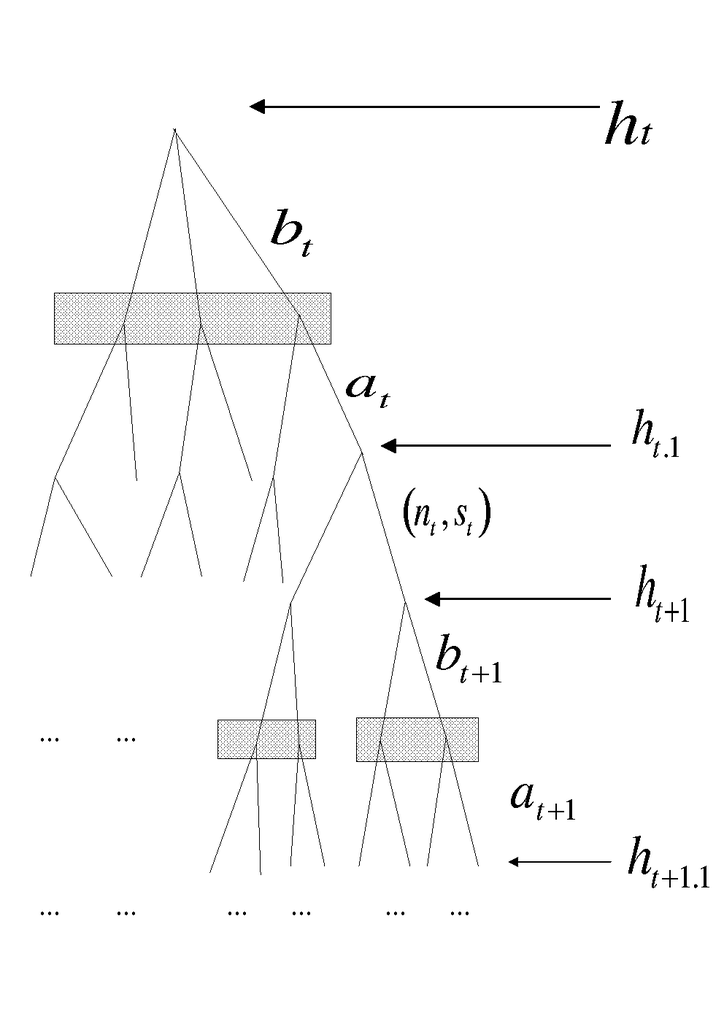

Since at stage $t$ the parent $t-1$ knows that his children will use the information regarding his observable actions, he will choose his actions in a manner that exploits the reactions of his children in most favorable way. Or in other words, parents may find it beneficial to manipulate their children’s behavior. In the above set-up, agents in later stages can use very complex punishment rules as their strategies. For instance, an agent $ t=5$ in stage 5 can condition his actions as follows:

> ‘’he will transfer a certain fraction $a_5$ of his income to his parents if his parents transferred a certain fraction $a_4$ of their income to the agent’s grandparents, saved certain amount $s_4$, had certain number of children, $n_4$, and if his grand parents transferred a certain fraction $ a_3$ of their income to the agent’s grand grand parents, … and so on.’’

While these types of strategies may lead to many subgame perfect equilibria, the equilibria that prescribe strategies conditioning on the dead grand parents are hard to execute since it is not possible to objectively verify if the agent’s grand parents or grand grand parents did such and such. I consider only pay-off relevant strategies: From equations ((2.2))-( {A4}), and the arguments of the utility function, it is clear that the only information from history that is relevant to decision making of the agents at stage $t$ is agent $t-1$’s own past decision regarding $ (s_{t-1},n_{t-1}),$ and thus I consider the bequest decision rule of agent $ t-1$ to be of the form $b_{t}\left( n_{t-1},s_{t-1}\right) ,$ and the old-age transfer decision rule of agent $t$ to be of the form $a_{t}\left( n_{t-1},s_{t-1}\right) ;$ similarly at stage $t.1,$ the agent $t$’s actions depend on his own past decision $a_{t}$ and his parent’s bequest decision $ b_{t},$ only through the net effect, $a_{t}w_{t}-b_{t}$ which I represent as functions of the form, $n_{t}=n_{t}\left( a_{t}w_{t}-b_{t}\right)$, and $ s_{t}=s_{t}(a_{t}w_{t}-b_{t}).$ Thus agent $t$’s strategies are functions of the type: $a_{t}=a_{t}(n_{t-1},s_{t-1})$, $n_{t}=n_{t}\left( a_{t}w_{t}-b_{t}\right)$, and $s_{t}=s_{t}(a_{t}w_{t}-b_{t})$ and $ b_{t+1}(n_{t},s_{t}).$ When actions at any stage are functions of past actions, they are generally known as *reaction functions.* Putting all the actions and reactions of agent t from all stages of the game together, we note that a *profile of pure strategies* of all agents together is given by,
$$\mathcal{A}_{t}=\left\{
\begin{array}{lc}
\left(
a_{t}(n_{t-1},s_{t-1}),n_{t}(a_{t}w_{t}-b_{t}),s_{t}(a_{t}w_{t}-b_{t}),b_{t+1}(n_{t},s_{t})\right)
& \text{for all agents }t\ge 1 \\
b_{1}(n_{0},s_{0}) & \text{for agent }t=0
\end{array}
\right. \text{ }$$
where, each component belongs to the relevant strategy spaces specified above. Note that agent $t$’s actions, $n_{t},s_{t},a_{t},$ and $b_{t+1}$ now belong to function spaces, whereas in open loop Nash equilibrium they were non-negative real numbers. I use the following characterization of the subgame perfect equilibrium notion.

### 3.1.1 The First Order Conditions for a Subgame Perfect Gift

Let $a_{t+1}(n_{t},s_{t})$, $n_{t+1}\left( a_{t+1}w_{t+1}-b_{t+1}\right)$, $ s_{t+1}(a_{t+1}w_{t+1}-b_{t+1})$ be the optimal reaction functions of agent $ t+1$, and let $n_{t-1}$, $s_{t-1}$ be any feasible actions of agent $t-1$. Taking these decisions as given, agent t chooses a feasible $\mathcal{A} _{t}=a_{t}(n_{t-1},s_{t-1}),$ $n_{t}(a_{t}w_{t}-b_{t}),$ $ s_{t}(a_{t}w_{t}-b_{t}),$ $b_{t+1}(n_{t},s_{t})$ that maximizes his utility. For $t>1$, the first order necessary conditions for his maximization problem are as follows:

**At stage t:**

$$\begin{equation}
\begin{array}{c}
\delta (n_{t-1})n_{t-1}\text{v}^{\prime }\stackrel{c_{t}^{t-1}}{(\overbrace{
(1+r_{t})s_{t-1}+a_{t}w_{t}n_{t-1}-n_{t-1}b_{t}})}... \\
-\alpha \text{v}^{\prime }(\stackrel{c_{t}^{t}}{\overbrace{
(1-a_{t})w_{t}-s_{t}-\theta _{t}n_{t}+b_{t}}})\le 0,\text{and }=0\;\text{if }
a_{t}>0
\end{array}
\tag{3.1}
\end{equation}$$

$$\begin{equation}
\begin{array}{c}
-\beta \text{v}^{\prime }(c_{t}^{t-1})n_{t-1}+\gamma (n_{t-1})\text{v}
^{\prime }(c_{t}^{t})\left[ 1-\theta _{t}n_{t}^{\prime
}(b_{t}-a_{t}w_{t})-s_{t}^{\prime }(b_{t}-a_{t}w_{t})\right] \le 0, \\
\text{ and }=0\text{ if }b_{t}>0
\end{array}
\tag{3.2}
\end{equation}$$

**At stage t.1:**

$$\begin{equation}
\begin{array}{c}
-\alpha \text{v}^{\prime }(c_{t}^{t})+\beta \text{v}^{\prime }(\stackrel{
c_{t+1}^{t}}{\overbrace{[1+r_{t+1})s_{t}+a_{t+1}\left( .\right)
w_{t+1}n_{t}-n_{t}b_{t+1}}}])\times \\
\;\left[ (1+r_{t+1})+w_{t+1}n_{t}a_{t+1,2}(n_{t},s_{t})\right] -\gamma
(n_{t})\text{v}^{\prime }(\stackrel{c_{t+1}^{t+1}}{\overbrace{
(1-a_{t+1})w_{t+1}-s_{t+1}-\theta _{t+1}n_{t+1}+b_{t+1}}})\times \\
\left[ a_{t+1,2}(n_{t},s_{t})w_{t+1}\right] \le 0, \text{and}=0\text{ if }
s_{t}>0
\end{array}
\tag{3.3}
\end{equation}$$

$$\begin{equation}
\begin{array}{c}
-\alpha \theta \text{v}^{\prime }(c_{t}^{t})+\beta \text{v}^{\prime
}(c_{t+1}^{t})\left[
a_{t+1}(n_{t},s_{t})w_{t+1}+n_{t}w_{t+1}a_{t+1,1}(n_{t},s_{t})\right] ... \\
+\gamma ^{\prime }(n_{t})\text{v}(c_{t+1}^{t+1})-\gamma (n_{t})\text{v}
^{\prime }(c_{t+1}^{t+1})\left[ w_{t+1}a_{t+1,1}(n_{t},s_{t})\right] \le 0,
\text{ and }=0\text{ if }n_{t}>0
\end{array}
\tag{3.4}
\end{equation}$$

Similar to open loop Nash equilibrium, we can define subgame perfect gift equilibrium and subgame perfect bequest equilibrium. However, in the rest of the paper we analyze only the properties of the subgame perfect gift equilibria.

In our framework, a subgame perfect equilibrium with differentiable reaction functions may not exist. Even if we assume that there exists one, it is not possible to compute all subgame perfect gift equilibrium reaction functions from the above first order conditions.[^5] Therefore, we explore the above system of equations to find a steady-state local subgame perfect gift equilibrium as follows: Let us assume that the wage rate $w_{t}=w,$ the interest rate $r_{t}=r,$ and the cost of raising children $\theta _{t}=\theta$ for all $t\geq 1.$

$$\begin{equation}
\Psi ^{a}\left( a\left( n\_,s\_\right) ,s+\theta n\right) \equiv \frac{
\delta (n_-)n_-}{\alpha }=\frac{\text{v}^{\prime }\left(
[1-a(.)]w-s-\theta n)\right) }{\text{v}^{\prime }\left(
(1+r)s_-+a(.)wn_-\right) } \tag{3.5}
\end{equation}$$

$$\begin{eqnarray}
\Psi ^{b}\left( a\left( n\_,s\_\right) ,s+\theta n\right) \equiv -\beta
\text{v}^{\prime }((1+r)s_-+a(.)wn_-)n_{\_}+\gamma (n_-).. &&
\nonumber \\
\text{v}^{\prime }\left( [1-a(.)]w-s-\theta n)\right) \left[ 1-\theta
n^{\prime }-s^{\prime }\right] \le 0\text{ and }=0\text{ if }b>0 &&
\tag{3.6}
\end{eqnarray}$$

$$\begin{equation}
\begin{array}{c}
\Psi ^{s}\left( a\left( n\_,s\_\right) ,a^{+}\left( n,s\right)
,a_{2}^{+}\left( n,s\right) ,n,s,s^{+}+\theta n^{+}\right) \equiv -\alpha
\text{v}^{\prime }\left( [1-a]w-s-\theta n)\right) ... \\
+\beta \text{v}^{\prime }\left( \left( 1+r\right) s+a^{+}\left( n,s\right)
nw\right) \left( (1+r)+nwa_{2}^{+}(n,s)\right) ... \\
-\gamma (n)\text{v}^{\prime }\left( [1-a(n,s)]w-s^{+}-\theta n^{+}\right)
\left[ a_{2}^{+}(n,s)w\right] \le 0\text{ and }=0\text{ if }s>0
\end{array}
\tag{3.7}
\end{equation}$$

$$\begin{equation}
\begin{array}{c}
\Psi ^{n}\left( a\left( n\_,s\_\right) ,a^{+}\left( n,s\right)
,a_{1}^{+}\left( n,s\right) ,n,s,s^{+}+\theta n^{+}\right) \equiv -\alpha
\theta \text{v}^{\prime }\left( [1-a]w-s-\theta n)\right) ... \\
+\beta \text{v}^{\prime }\left( (1+r)+wna^{+}(n,s)\right) \left[
a^{+}(n,s)w+a_{1}^{+}(n,s)wn\right] ... \\
+\gamma ^{\prime }(n)\text{v}\left( [1-a^{+}(n,s)]w-s^{+}-\theta
n^{+}\right) ... \\
-\gamma (n)\text{v}^{\prime }\left( [1-a^{+}(n,s)]w-s^{+}-\theta
n^{+}\right) \left[ a_{1}^{+}(n,s)w\right] \le 0,\text{ and }=0\text{ if }n>0
\end{array}
\tag{3.8}
\end{equation}$$

# 4 Convention, Learning, and Subgame Perfect Gift Equilibrium

In the previous section we saw that it is not possible to compute a subgame perfect gift equilibrium even locally around a steady-state using the first order conditions. Furthermore, there are generally multiple subgame perfect equilibria, and the the literature on equilibrium selection theory does not guide us in the overlapping generations context to select an equilibrium. To make progress, I follow the recent developments in evolutionary game theory for repeated normal form finite games. To overcome the computational difficulties and equilibrium selection problems, as in finite games, I impose a bounded rationality assumption on individual behaviors, and the selection mechanism in the aggregate to evolve in an evolutionary process with or without learning.

Much of the evolutionary game theory literature assumes that a game with finite number of pure strategies is played repeatedly many times by randomly drawn players from a large population. It combines two processes: a selection process that postulates which strategies yield higher pay-offs given the actions of all players, and a mutation process which randomly creates exceptions to the evolutionary process. There are many ways the selection process has been modeled, for instance, as natural selection, imitation, reinforcement and best response. I will consider best response model with a boundedly rational expectation about other agent’s behavior.

## 4.1 The Gift Equilibrium with a Fixed Convention

The bounded rationality of this paper consists of three assumptions: **First**, at every stage $t,$ each agent follows a common ’‘**convention**’’ that if he transfers a fraction $a_{t}$ of his income to his old-parents at stage $t,$ then he spends $S_{t}=\sigma \left( a_{t}\right)$ on savings for old-age and on children at stage $t.1$. Here $\sigma \left( .\right)$ is the convention. It is common to all individuals. It could be viewed as a threat strategy that a child may use if his parent did not save enough for old-age. **Second**, each agent assumes that his children will react to his decisions exactly the way he reacts to his parent’s decisions, that is the reaction $a\left( {}\right)$ that he chooses will be also the reaction function of his children. **Third**, given a convention $\sigma \left( {}\right) ,$ an individual chooses an action that maximizes his utility, i.e., individual behavior is guided by best response given a convention $ ( {})$ and assumption about other’s behavior.

The above bounded rationality assumption is very strong and not self-fulfilling in the sense that assuming that a convention $\sigma ^{\prime }$ will be followed at stage $t.1,$ the parents will make their bequest decision $b=0$ and an adult child will make his old-age transfer decision $a$ at stage $t$ that maximize their respective utility functions. But when the game moves to stage $t.1,$ the children make their best responses $n\left( a\right)$ and $s\left( a\right)$ given $a$ which may not satisfy the convention that was assumed at stage $t,$ i.e., $\bar{\sigma} ^{\prime }\left( a^{*}\right) \equiv s^{\prime }\left( a^{*}\right) +\theta n^{\prime }\left( a^{*}\right)$ may not be equal to $\sigma ^{\prime }$ that was assumed at stage $t$, i.e. his decisions are not time-consistent. But when it holds, we have the following result:

**Proposition 4.1** Let $\left( a^{*},n^{*},s^{*}\right)$ and $\left( a\left( .\right) ,s\left( {}\right) ,n\left( {}\right) \right)$ be a stationary gift equilibrium with a fixed convention $\sigma ^{\prime }.$ If $s^{\prime }\left( a^{*}\right) +\theta n^{\prime }\left( a^{*}\right) =\sigma ^{\prime }$ *holds then the stationary gift equilibrium with convention* $\sigma ^{\prime }$ *is also a stationary local subgame perfect gift equilibrium.*

Notice that the fixed convention $\sigma \left( .\right)$ corresponding to a subgame perfect equilibrium does not have time inconsistency problem mentioned above. But how do individuals in societies arrive at a convention? I address this in the next subsection.

## 4.2 The Gift Equilibrium with Learned Conventions

In the previous subsection I assumed that individuals somehow know the subgame perfect convention $\sigma ^{\prime }$. In this section I formulate an evolutionary process for convention using a learning mechanism, and establish that when the process converges, the limit convention gives a stationary local subgame perfect gift equilibrium. This learning procedure is then used later to compute a stationary local subgame perfect gift equilibrium numerically.

### 4.2.1 Learning

Initially at time $t=1,$ the economy begins with a fixed convention $\sigma _{0}^{\prime }$ and calculates $\left( a_{1}^{*},n_{1}^{*},s_{1}^{*}\right)$ and $\left( a_{1}\left( .\right) ,s_{1}\left( {}\right) ,n_{1}\left( {}\right) \right)$ that are consistent with the conditions of a stationary gift equilibrium with a fixed convention $\sigma _{0}^{\prime }.$ In period $t=1,$ the agents watch and learn from their parents choices $s_{1}\left( {}\right) ,n_{1}\left( {}\right)$ and update their convention to $\sigma _{1}^{\prime }$ using the formula $\sigma _{1}^{\prime }=$ $s_{1}^{\prime }\left( a_{2}^{*}\right) +\theta n_{1}^{\prime }\left( a_{2}^{*}\right) ,$ where $a_{2}^{*}$ corresponds to the stationary gift equilibrium with fixed convention $\sigma _{1}^{\prime }.$ Similarly at any time $t,$ given convention $\sigma _{t-1}^{\prime }$of the previous period, the society learns a convention $\sigma _{t}^{\prime }$. Denote the relationship between the learned convention of period $t$ as a function of the convention used by the parent’s generation by $\sigma _{t}^{\prime }=\Psi \left( \sigma _{t-1}^{\prime }\right) .$ When the process converges, the limiting convention $\sigma ^{\prime *}$ satisfies the condition of the previous proposition, and hence gives us a stationary local subgame perfect gift equilibrium. This is depicted in the phase diagram in Figure 4.1.

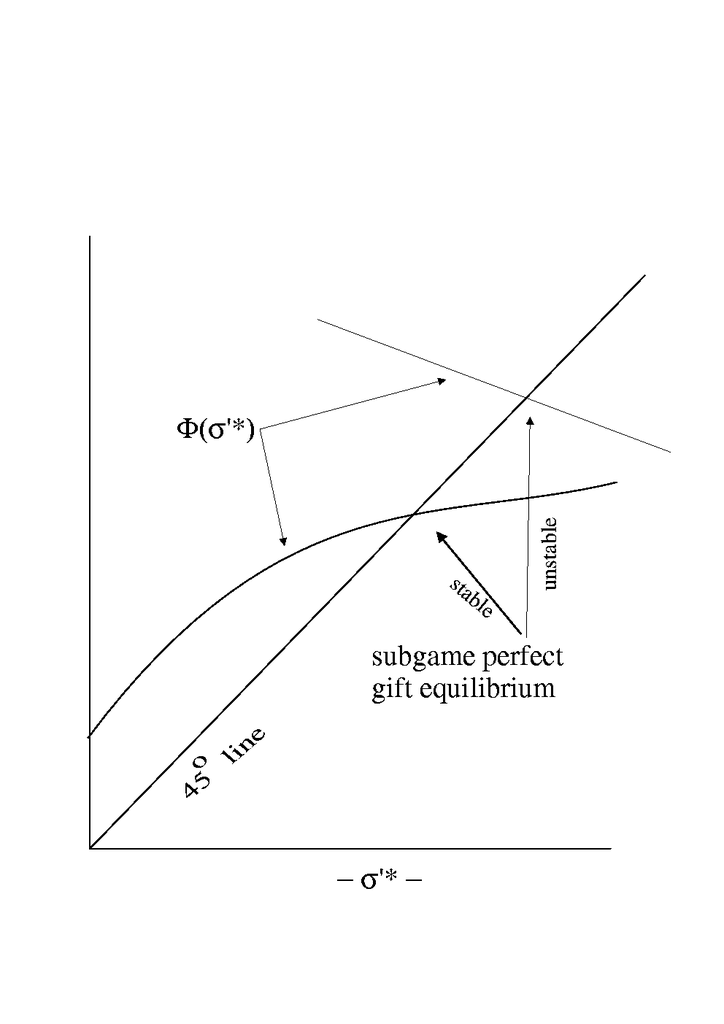

Figure 4.1: Phase diagram of Learning dynamics

## 4.3 Properties of Stationary Gift Equilibrium with Fixed Convention

While the effect of parents savings is negative on the transfers from children, the corresponding effect of number of children could be ambiguous. To show this, let us denote by $\phi (n)\equiv \delta (n).n/\alpha$ and assume that $\phi (n)$ is an increasing function of $n$. Proceeding in the same manner as in the proof of above proposition, we can derive that
$$\frac{\partial a(.,.)}{\partial n}=-\frac{\phi ^{\prime }(n)\text{v}^{\prime
}(c_2^{*})+\left[ \phi (n)a(.,.)w\text{v}^{\prime \prime }(c_2^{*})\right] }{
\left[ w\text{v}^{\prime \prime }(c_1^{*})(1+\sigma ^{\prime *})+\phi (n)wn
\text{v}^{\prime \prime }(c_2^{*})\right] }$$
Note that both bracketed terms in the above are negative and the first term of the numerator is positive. Thus the sign of the right hand side of the above partial derivative will depend on the relative magnitudes of the bracketed terms and the first term on the numerator. In the numerical example for CEM economy that we consider later, the right hand side is unambiguously negative, which means that if parents have more children, they will receive less gifts from each child.

Although, a threat to parents by the children of the type $\sigma ^{\prime *}=\infty$ leads to open-loop Nash equilibrium but it is incredible since it sounds like:

> “if his parents choose levels of fertility and saving different from that are prescribed by the open loop Nash-equilibrium level $n^{*},s^{*}$ and thus induce him to transfer more (resp. less) amount than that is prescribed by open-loop Nash equilibrium, he will consume nothing (resp. consume everything that he has, and if necessary he will borrow against his children) during his adult age.”

A feasible steady-state allocation is said to be *Pareto Optimal* if there does not exist another feasible steady-state allocation that gives higher utility to a representative agent.[^6]

It is clear that if the agents optimally adjust their fertility and savings decisions, the gains in utility will be even higher.

## 4.4 The CEM Example Continued

Table 4.1: Steady-state local learning and subgame perfect gift equilibria

[output not shown]

In panels (a) and (b) of figure 4.2 corresponding to the cases $s=0$ and $s>0$, we have plotted the graph of $\Phi (\sigma ^{\prime *})$ around its fixed points. $\tau$ in this figure represents social security tax rate that we will consider later.

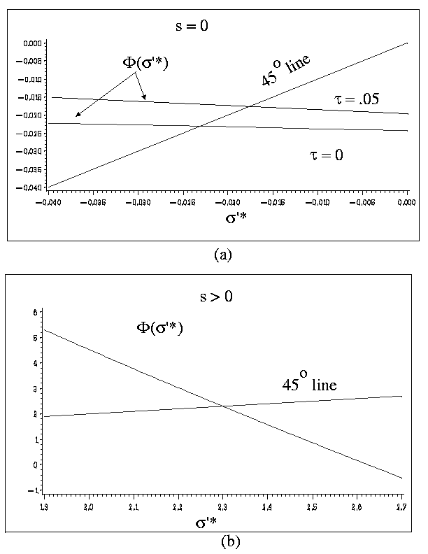

Figure 4.2: Phase diagram of learning equilibrium for numerical CEM economy

# 5 Social security and its effects

We have seen in our previous results that parents do have incentives to manipulate to receive a higher percentage of their children’s income transferred to them. In this section we examine the effects of introducing a pay-as-you-go social security which can directly reduce or even eliminate the need for manipulation to effect old-age supports. We study the effects of social security on the rate of voluntary old-age transfers, fertility, savings, both at the individual level and the aggregate level. We illustrate these effects using CEM economy for analytical simplicity.

$$\begin{equation}
a(n,s)=\frac{(\delta _0/\alpha )^{1/\rho }n^{\delta _1/\rho }\left( w-\tau
w-\left[ s^{*}+\theta n^{*}-a^{*}\sigma ^{\prime *}\right] \right)
-(1+r)s-n\tau w}{w\left( n+\left( 1+\frac{\sigma ^{\prime ^{*}}}w\right)
(\delta _0/\alpha )^{1/\rho }n^{\delta _1/\rho }\right) } \tag{5.1}
\end{equation}$$

We have assumed in our main analysis that parents cannot leave a debt to be paid by their children, i.e., we have assumed $s_t\geq 0,$ not negative. Suppose we allow $s_t$ to be negative, i.e., some parents are net dissavers in the society (which is observed for some agents in less developed countries), then social security may reduce the magnitude of dissavings of these agents and the aggregate savings might even go-up as a result.

In our view, one of the motives for introduction of social security is to overcome the incentives to throw oneself to the mercy of the younger generation in old-age. Our view of social security is different from the social insurance view put forward by Diamond and Mirrlees (1978) %Diamond-Mirrlees [1978] and others. The purpose of social security is clearly more to force people to save for their retirement since we all know that we would not be able to let the elderly live miserably if they do not save for their retirement. Our view of social security is close to the social conscience view except that in our context the social conscience is extended to the family members only.

In our model, similar to Veall (1986), %Veall [1986], social security benefits and taxes are endogenously determined. As in the Hansson and Stuart model, a social security tax-benefits stream for the current as well as all future generations that is implied by the subgame perfect gift equilibrium could be legislated by the living generations in period $t=1$ and no future generations will have incentives to change it.

# 6 Conclusion

In this paper we have considered a pure exchange overlapping generations model with two-sided limited altruism in the sense that agents care not only about their own life-cycle consumption, but they also care about their parents’ old-age consumption and their children’s adult-age consumption. In our economy agents decide their levels of fertility, savings, and transfers of resources to parents and children. We argue that the commonly used open-loop Nash equilibrium does not fully take into account the incentives that agents may have to manipulate their children’s or parents’ behavior to effect higher rate of transfers.

We use more appropriate sequential multi-stage game in extensive form to model the manipulative behavior of agents and the notion of subgame perfect equilibrium to characterize the optimal manipulative behaviors. Our analysis is locally around steady-state equilibria. We show that there may exist multiple subgame perfect equilibria, and it is generally not possible to select a particular subgame perfect equilibrium as more reasonable description of actual behavior than other equilibria; furthermore, computation of subgame perfect equilibria in overlapping generations framework has been problematic since it involves computation of fixed points in function spaces, and thus studying the general properties of subgame perfect equilibria has been extremely cumbersome. We introduce a notion of local learning equilibrium, rationalizing it to describe a form of bounded rational human behavior in the sense that children learn certain behaviors from their parents or neighbors. We demonstrate that the computation of local subgame perfect equilibrium reduces to an easier problem of finding a particular type of local learning equilibrium, which is, indeed, a fixed point of a function of a single variable. We also show that a set of local learning equilibrium paths converge to local subgame perfect equilibrium in the long-run; we name such subgame perfect equilibrium as stable. Using this as a reasonable equilibrium selection criterion, we demonstrate that for a class of CEM (i.e., constant elasticity of marginal utility) economies this criterion selects a unique local subgame perfect equilibrium out of two local subgame perfect gift equilibria.

We further show that for all types of equilibria, the equilibrium rate of old-age support to parents depend negatively with their parents’ savings and the number of children (the latter is true for CEM economy). The total amount of transfers from children may go down as parents choose more children, and this is in contrast to the traditional view of old-age security view for child bearing. Thus with a manipulative behavior of choosing less savings, and more or less children, depending on the economy, agents can extract higher rate of old-age support from children. For the CEM economy, the stable local subgame perfect equilibrium has zero savings, higher fertility and old-age support and it is Pareto superior as compared to the other subgame perfect equilibrium with positive savings. Thus by manipulation, individuals can effect higher rate of old-age supports from children and for this a social security may not be necessary. In our view, one of the reasons for introduction of social security is to overcome the incentives to throw oneself to the mercy of the younger generation in old-age. We have also examined the effect of social security on subgame perfect equilibrium rate of population growth and aggregate savings rate.

# References

Barro, Robert J. 1974. “Are Government Bonds Net Wealth?” Macro Dyn. *Journal of Political Economy* 82 (6): 1095–1117. https://doi.org/10.1086/260266.

Barro, Robert J., and Gary S. Becker. 1989. “Fertility Choice in a Model of Economic Growth.” *Econometrica* 57 (2): 481–501. https://doi.org/10.2307/1912563.

Becker, Gary S. 1974. “A Theory of Social Interactions.” Transfers. *Journal of Political Economy* 82 (6): 1063–93. https://doi.org/10.1086/260265.

Bernheim, B. Douglas, Andrei Shleifer, and Lawrence H. Summers. 1986. “The Strategic Bequest Motive.” Transfers. *Journal of Labor Economics* 4 (3, Part 2): S151–S182. https://doi.org/10.1086/298126.

Browning, EDGAR K. 1975. “Why the Social Insurance Budget Is Too Large in a Democracy.” *Economic Inquiry* 13 (3): 373–88. https://doi.org/10.1111/j.1465-7295.1975.tb00255.x.

Diamond, P. A. 1977. “A Framework for Social Security Analysis.” Social Security. *Journal of Public Economics* 8 (3): 275–98. https://doi.org/10.1016/0047-2727(77)90002-0.

Diamond, P. A., and J. A. Mirrlees. 1978. “A Model of Social Insurance with Variable Retirement.” *Journal of Public Economics* 10 (3): 295–336. https://doi.org/10.1016/0047-2727(78)90050-6.

Hansson, Ingemar, and Charles Stuart. 1989. “Social Security as Trade Among Living Generations.” Social Security. *The American Economic Review* 79 (5): 1182–95. http://www.jstor.org/stable/1831444.

Kohlberg, Elon. 1976. “A Model of Economic Growth with Altruism Between Generations.” *Journal of Economic Theory* 13 (1): 1–13. https://doi.org/10.1016/0022-0531(76)90062-4.

Nishimura, Kazuo, and Junsen Zhang. 1992. “Pay-as-You-Go Public Pensions with Endogenous Fertility.” *Journal of Public Economics* 48 (2): 239–58. https://doi.org/10.1016/0047-2727(92)90029-F.

Nugent, Jeffrey B. 1985. “The Old-Age Security Motive for Fertility.” Social Security. *Population and Development Review* 11 (1): 75. https://doi.org/10.2307/1973379.

Pollak, Robert A. 1988. “Tied Transfers and Paternalistic Preferences.” *American Economic Review*.

Raut, Lakshmi K. 1992. “Demographic Links to Savings in Life Cycle Models: Identification of Issues for LDCs.” Published: Aging - General. *The Indian Economic Journal*.

———. 1990. “Capital Accumulation, Income Distribution and Endogenous Fertility in an Overlapping Generations General Equilibrium Model.” Published. *Journal of Development Economics* 34 (1-2): 123–50. https://doi.org/10.1016/0304-3878(90)90079-q.

Samuelson, Paul A. 1958. “An Exact Consumption-Loan Model of Interest with or Without the Social Contrivance of Money.” OLG. *Journal of Political Economy* 66 (6): 467–82. https://doi.org/10.1086/258100.

Veall, Michael R. 1986. “Public Pensions as Optimal Social Contracts.” Population. *Journal of Public Economics* 31 (2): 237–51. https://doi.org/10.1016/0047-2727(86)90020-4.